# Sea Ice test

```r
library(rstan)
library(gdata)
library(bayesplot)
```

Read in file and drop one row with no data:

```r
seaIce <- read.csv("iceData.csv")
seaIce <- seaIce[-c(10), ]
```

Look at data

```r
head(seaIce)
```

|  | year | mo | data.type | region | extent | area |
| --- | --- | --- | --- | --- | --- | --- |
| 1 | 1979 | 1 | Goddard | N | 15.41 | 12.41 |
| 2 | 1980 | 1 | Goddard | N | 14.86 | 11.94 |
| 3 | 1981 | 1 | Goddard | N | 14.91 | 11.91 |
| 4 | 1982 | 1 | Goddard | N | 15.18 | 12.19 |
| 5 | 1983 | 1 | Goddard | N | 14.94 | 12.01 |
| 6 | 1984 | 1 | Goddard | N | 14.47 | 11.68 |

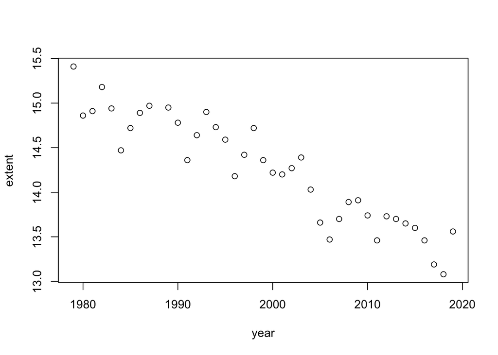

```r
plot(extent ~ year, data = seaIce)
```

Now run a general linear model and add line to plot

```r
lm1 <- lm(extent ~ year, data = seaIce)
summary(lm1)
```

```
##
## Call:
## lm(formula = extent ~ year, data = seaIce)
##
## Residuals:
##      Min       1Q   Median       3Q      Max
## -0.49017 -0.19101  0.05159  0.13067  0.41324
##
## Coefficients:
##               Estimate Std. Error t value Pr(>|t|)
## (Intercept) 107.557756   5.865469   18.34   <2e-16 ***
## year         -0.046672   0.002934  -15.91   <2e-16 ***
## ---
## Signif. codes:  0 '***' 0.001 '**' 0.01 '*' 0.05 '.' 0.1 ' ' 1
##
## Residual standard error: 0.2199 on 38 degrees of freedom
## Multiple R-squared:  0.8695, Adjusted R-squared:  0.866
## F-statistic: 253.1 on 1 and 38 DF,  p-value: < 2.2e-16
```

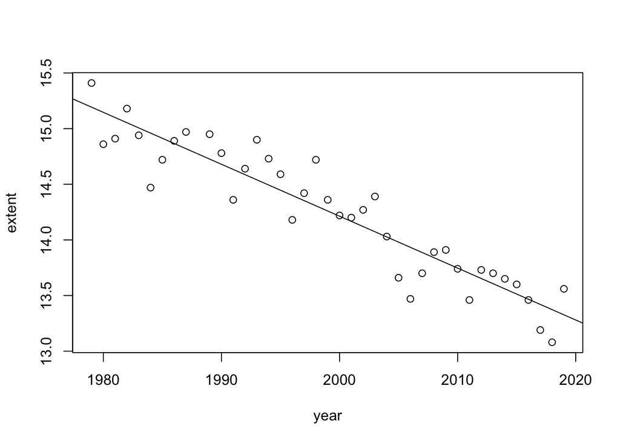

```r
plot(extent ~ year, data = seaIce)
abline(lm1)
```

Reformat data to start at year 0 and rerun linear model

```r
extent <- seaIce$extent
year <- I(seaIce$year - 1978)
N <- length(seaIce$year)

stan_data <- list(N = N, year = year, extent = extent)

lm1 <- lm(extent ~ year)
summary(lm1)
```

```
##
## Call:
## lm(formula = extent ~ year)
##
## Residuals:
##      Min       1Q   Median       3Q      Max
## -0.49017 -0.19101  0.05159  0.13067  0.41324
##
## Coefficients:
##              Estimate Std. Error t value Pr(>|t|)
## (Intercept) 15.240200   0.071443  213.32   <2e-16 ***
## year        -0.046672   0.002934  -15.91   <2e-16 ***
## ---
## Signif. codes:  0 '***' 0.001 '**' 0.01 '*' 0.05 '.' 0.1 ' ' 1
##
## Residual standard error: 0.2199 on 38 degrees of freedom
## Multiple R-squared:  0.8695, Adjusted R-squared:  0.866
## F-statistic: 253.1 on 1 and 38 DF,  p-value: < 2.2e-16
```

```r
lm_alpha <- summary(lm1)$coeff[1]  # the intercept
lm_beta <- summary(lm1)$coeff[2]  # the slope
lm_sigma <- sigma(lm1)  # the residual error
```

Load in an run stan model

```r
stan_model <- "seaIceModel.stan"
fit <- stan(file = stan_model, data = stan_data, warmup = 500, iter = 1000, chains = 4, cores = 2, thin = 1)
```

```
## hash mismatch so recompiling; make sure Stan code ends with a blank line
```

Examine fit

```r
fit
```

```
## Inference for Stan model: seaIceModel.
## 4 chains, each with iter=1000; warmup=500; thin=1;
## post-warmup draws per chain=500, total post-warmup draws=2000.
##
##              mean se_mean   sd  2.5%   25%   50%   75% 97.5% n_eff Rhat
## alpha       15.24    0.00 0.07 15.10 15.20 15.24 15.29 15.38   956    1
## beta        -0.05    0.00 0.00 -0.05 -0.05 -0.05 -0.04 -0.04  1008    1
## sigma        0.23    0.00 0.03  0.18  0.21  0.22  0.24  0.29   815    1
## ext_rep[1]  15.20    0.01 0.23 14.75 15.04 15.20 15.35 15.66  1982    1
## ext_rep[2]  15.15    0.01 0.24 14.67 14.99 15.15 15.31 15.63  1775    1
## ext_rep[3]  15.10    0.01 0.23 14.65 14.94 15.09 15.26 15.56  1939    1
## ext_rep[4]  15.05    0.01 0.24 14.61 14.89 15.05 15.21 15.51  1809    1
## ext_rep[5]  15.01    0.01 0.24 14.54 14.85 15.00 15.16 15.47  1879    1
## ext_rep[6]  14.97    0.01 0.24 14.50 14.81 14.96 15.12 15.44  1869    1
## ext_rep[7]  14.92    0.01 0.24 14.44 14.76 14.92 15.07 15.39  2027    1
## ext_rep[8]  14.88    0.01 0.24 14.40 14.72 14.88 15.03 15.33  1770    1
## ext_rep[9]  14.83    0.01 0.23 14.35 14.68 14.83 14.98 15.28  1828    1
## ext_rep[10] 14.72    0.01 0.23 14.27 14.56 14.73 14.88 15.18  1540    1
## ext_rep[11] 14.68    0.01 0.23 14.23 14.53 14.68 14.84 15.15  2025    1
## ext_rep[12] 14.64    0.01 0.23 14.18 14.49 14.64 14.79 15.08  2061    1
## ext_rep[13] 14.59    0.01 0.23 14.15 14.44 14.59 14.75 15.05  1756    1
## ext_rep[14] 14.54    0.00 0.23 14.10 14.38 14.53 14.69 14.98  2203    1
## ext_rep[15] 14.49    0.01 0.23 14.03 14.34 14.49 14.65 14.96  1903    1
## ext_rep[16] 14.44    0.01 0.23 13.96 14.29 14.44 14.59 14.90  1940    1
## ext_rep[17] 14.40    0.01 0.23 13.92 14.24 14.40 14.55 14.84  2037    1
## ext_rep[18] 14.36    0.01 0.23 13.93 14.20 14.35 14.51 14.83  1950    1
## ext_rep[19] 14.30    0.01 0.23 13.89 14.15 14.30 14.45 14.76  2055    1
## ext_rep[20] 14.26    0.01 0.23 13.80 14.10 14.25 14.41 14.71  1931    1
## ext_rep[21] 14.21    0.00 0.23 13.77 14.06 14.21 14.35 14.67  2180    1
## ext_rep[22] 14.16    0.00 0.23 13.69 14.02 14.17 14.32 14.61  2159    1
## ext_rep[23] 14.12    0.01 0.23 13.69 13.98 14.12 14.27 14.56  1762    1
## ext_rep[24] 14.07    0.01 0.24 13.60 13.92 14.07 14.22 14.52  1815    1
## ext_rep[25] 14.03    0.01 0.23 13.59 13.87 14.02 14.18 14.47  1783    1
## ext_rep[26] 13.98    0.01 0.23 13.53 13.82 13.98 14.13 14.41  1956    1
## ext_rep[27] 13.94    0.01 0.23 13.48 13.79 13.94 14.08 14.40  1872    1
## ext_rep[28] 13.87    0.01 0.23 13.42 13.72 13.88 14.03 14.35  2074    1
## ext_rep[29] 13.84    0.01 0.23 13.40 13.69 13.84 13.98 14.29  1863    1
## ext_rep[30] 13.79    0.01 0.24 13.30 13.64 13.79 13.95 14.29  1858    1
## ext_rep[31] 13.75    0.01 0.23 13.31 13.60 13.75 13.91 14.19  1987    1
## ext_rep[32] 13.70    0.01 0.22 13.27 13.55 13.70 13.84 14.14  1907    1
## ext_rep[33] 13.65    0.01 0.23 13.21 13.49 13.65 13.80 14.11  1932    1
## ext_rep[34] 13.60    0.01 0.24 13.14 13.44 13.60 13.76 14.07  1905    1
## ext_rep[35] 13.56    0.01 0.23 13.12 13.41 13.56 13.71 14.04  2033    1
## ext_rep[36] 13.51    0.01 0.23 13.07 13.36 13.51 13.67 14.01  1918    1
## ext_rep[37] 13.47    0.01 0.24 13.01 13.30 13.47 13.63 13.93  1914    1
## ext_rep[38] 13.41    0.01 0.24 12.95 13.26 13.41 13.57 13.88  1862    1
## ext_rep[39] 13.37    0.01 0.24 12.91 13.21 13.37 13.52 13.82  1930    1
## ext_rep[40] 13.33    0.01 0.24 12.86 13.17 13.33 13.48 13.81  1974    1
## lp__        38.62    0.05 1.31 35.20 38.10 38.95 39.53 39.99   616    1
##
## Samples were drawn using NUTS(diag_e) at Tue Jan 21 16:36:22 2020.
## For each parameter, n_eff is a crude measure of effective sample size,
## and Rhat is the potential scale reduction factor on split chains (at
## convergence, Rhat=1).
```

```r
posterior <- extract(fit)
str(posterior)
```

```
## List of 5
##  $ alpha  : num [1:2000(1d)] 15.2 15.3 15.2 15.1 15.3 ...
##   ..- attr(*, "dimnames")=List of 1
##   .. ..$ iterations: NULL
##  $ beta   : num [1:2000(1d)] -0.0468 -0.0453 -0.0458 -0.042 -0.0488 ...
##   ..- attr(*, "dimnames")=List of 1
##   .. ..$ iterations: NULL
##  $ sigma  : num [1:2000(1d)] 0.217 0.212 0.201 0.255 0.179 ...
##   ..- attr(*, "dimnames")=List of 1
##   .. ..$ iterations: NULL
##  $ ext_rep: num [1:2000, 1:40] 15.3 15.1 15.4 14.8 15.6 ...
##   ..- attr(*, "dimnames")=List of 2
##   .. ..$ iterations: NULL
##   .. ..$           : NULL
##  $ lp__   : num [1:2000(1d)] 40.1 38.5 39.4 38.1 37.9 ...
##   ..- attr(*, "dimnames")=List of 1
##   .. ..$ iterations: NULL
```

Plot comparing to earlier linear prediction. Black dashes is linear, red line is stan.

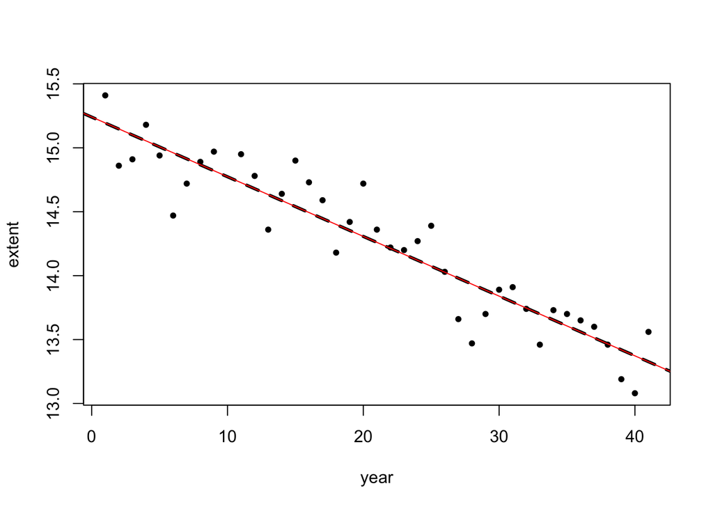

```r
plot(extent ~ year, pch = 20)

abline(lm1, col = 1, lty = 2, lw = 3)
abline(mean(posterior$alpha), mean(posterior$beta), col = 2, lw = 1)
```

These are identical because it is a very simple linear model with only weakly informative parameters.

You can visualize the variability by plotting multiple estimates from the posterior.

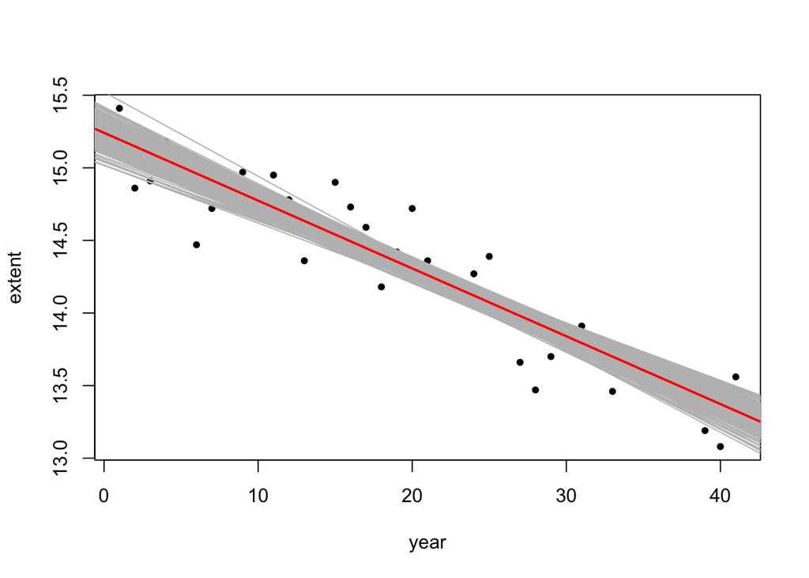

```r
plot(extent ~ year, pch = 20)

for (i in 1:500) {
 abline(posterior$alpha[i], posterior$beta[i], col = "gray", lty = 1)
}

abline(mean(posterior$alpha), mean(posterior$beta), col = 2, lw = 2)
```

Look at traceplots to see convergence. Can do this either directly referencing the posterior or by calling traceplot.

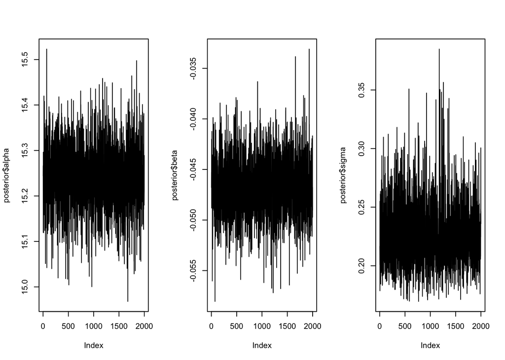

```r
par(mfrow = c(1,3))
plot(posterior$alpha, type = "l")
plot(posterior$beta, type = "l")
plot(posterior$sigma, type = "l")
```

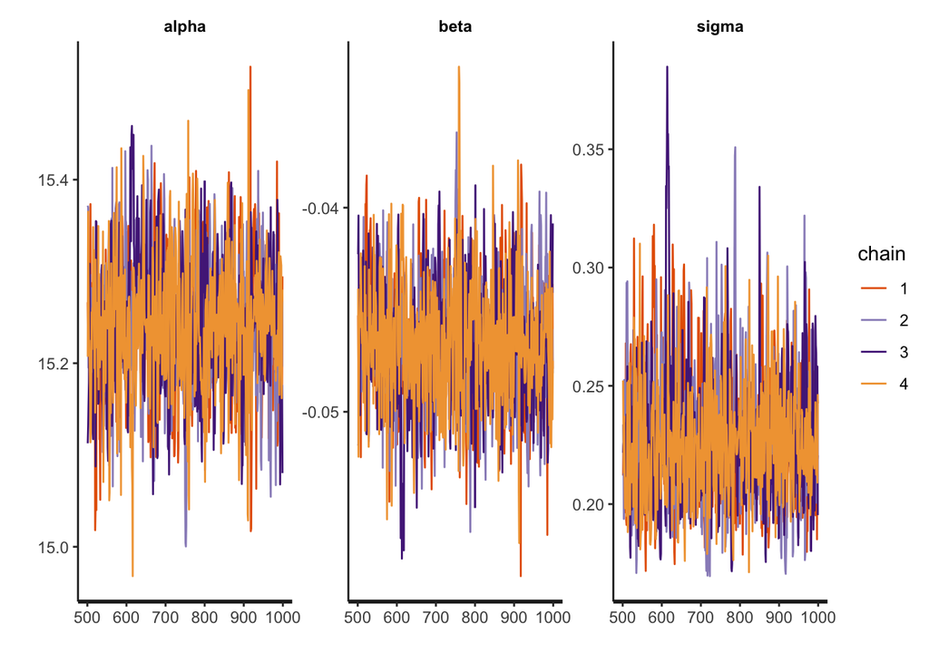

```r
traceplot(fit,pars=c("alpha","beta","sigma"))
```

Plot the posterior distributions, as well as the values from the linear fit to compare. Can do either by referencing posterior or by using stan_dens().

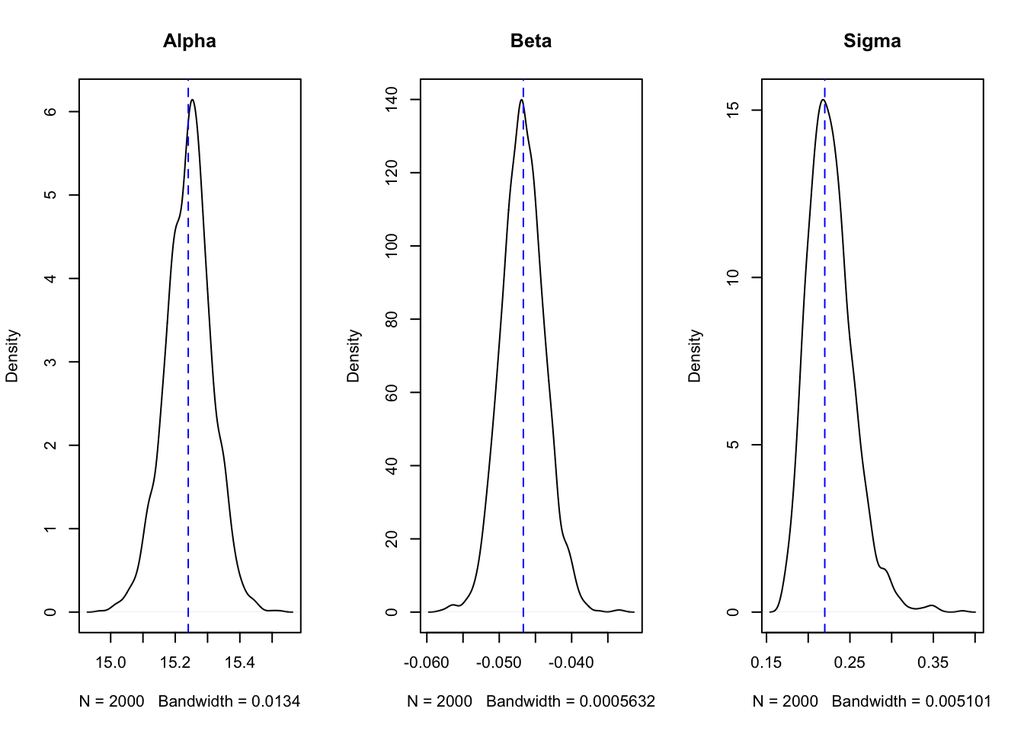

```r
par(mfrow = c(1,3))

plot(density(posterior$alpha), main = "Alpha")
abline(v = lm_alpha, col = 4, lty = 2)

plot(density(posterior$beta), main = "Beta")
abline(v = lm_beta, col = 4, lty = 2)

plot(density(posterior$sigma), main = "Sigma")
abline(v = lm_sigma, col = 4, lty = 2)
```

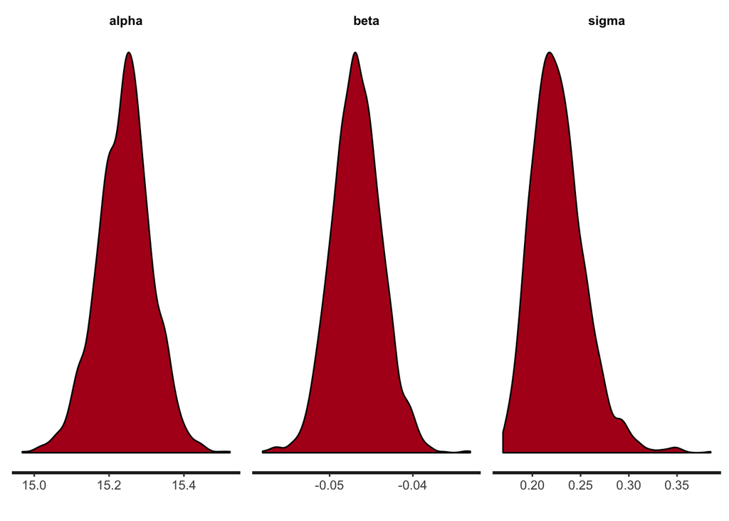

```r
stan_dens(fit,pars=c("alpha","beta","sigma"))
```

Can also calculate the probability that a certain parameter is above or below some value. In this case the probability that ice has been increasing.

```r
sum(posterior$beta>0)/length(posterior$beta)
```

```
## [1] 0
```

Can plot values and credible intervals for parameters. In this case the 95% intervals are so small that you can’t see them.

```
## ci_level: 0.5 (50% intervals)
```

```
## outer_level: 0.95 (95% intervals)
```

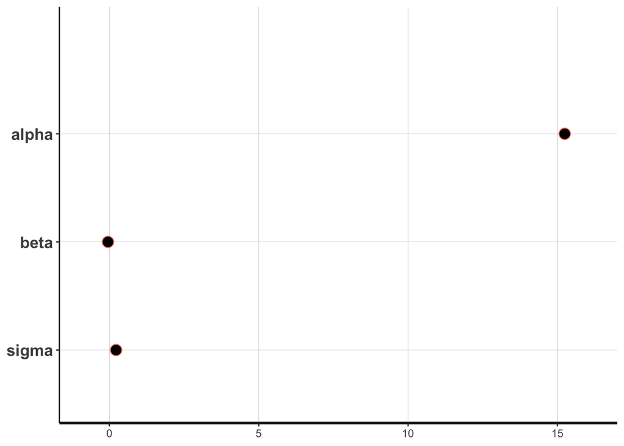

```r
plot(fit,pars=c("alpha","beta","sigma"),show_density = FALSE, ci_level = 0.5, outer_level = 0.95, fill_color = "salmon")
```

In the generated quantities section I had stan generate predicted values using rng for each data point.

```r
ext_rep <- as.matrix(fit, pars = "ext_rep")
dim(ext_rep)
```

```
## [1] 2000   40
```

Can compare density of y with density of predicted values

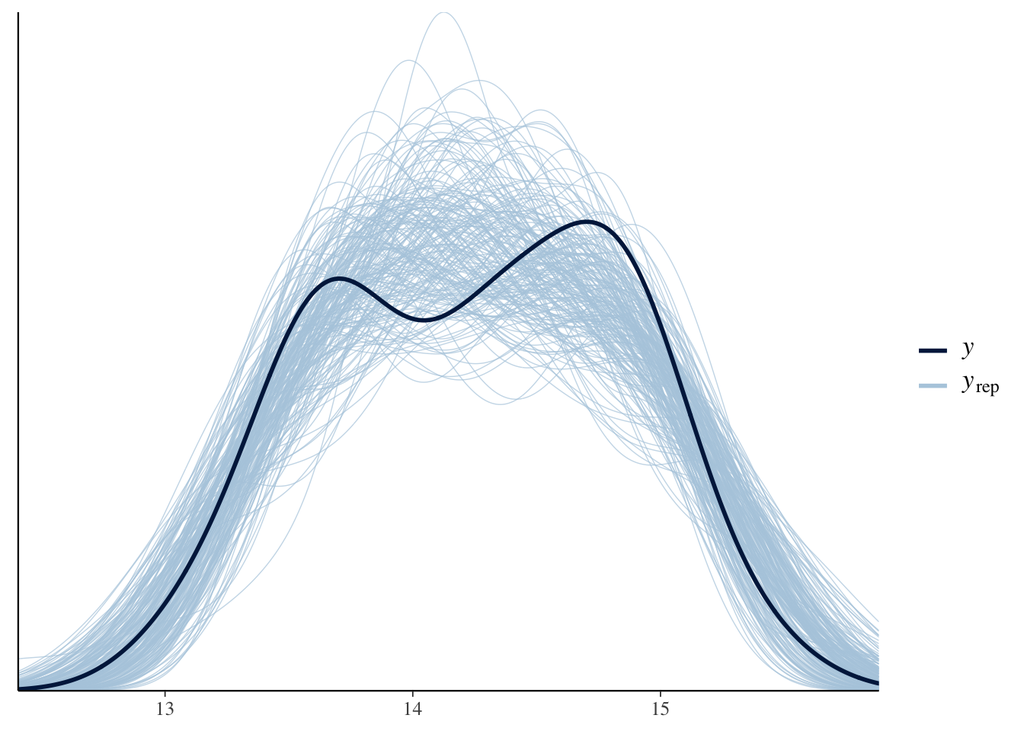

```r
ppc_dens_overlay(extent, ext_rep[1:200, ])
```